# Time Series Cross-Validation

A key assumption for time series cross-validation is the independent and identical (iid) distribution of the samples available for training. For financial data, this is often not the case. Financial data is neither independently nor identically distributed because of `serial correlation` and time-varying standard deviation, also known as `heteroskedasticity`.

## Time series cross-validation with sklearn

- The `TimeSeriesSplit` in the `sklearn.model_selection` module aims to address the linear order of time-series data.
- To address time dependency, the `sklearn.model_selection.TimeSeriesSplit` object implements a walk-forward test with an expanding training set, where subsequent training sets are supersets of past training sets.

```python
from sklearn.model_selection import TimeSeriesSplit
from sklearn.model_selection import KFold
import numpy as np
import matplotlib.pyplot as plt
from matplotlib.patches import Patch
import seaborn as sns

import sklearn
from sklearn.linear_model import ElasticNet
from sklearn.multioutput import MultiOutputRegressor
from sklearn.model_selection import cross_val_score
from sklearn.model_selection import GridSearchCV

np.random.seed(1338)
cmap_data = plt.cm.Paired
cmap_cv = plt.cm.coolwarm
n_splits = 5
```

```python
import pandas as pd
from pandas_datareader import data as web
import warnings
warnings.filterwarnings('ignore')
```

# Data

- Generate `100` random data points with `3` different imbalanced classes for `X` and `y` data.

```python
# random data points
n_points = 100
n_features = 10
X = np.random.randn(n_points, n_features)

# imbalanced  classes
percentiles_classes = [.2, .3, .5]
y = np.hstack([[ii] * int(n_points * perc)
               for ii, perc in enumerate(percentiles_classes)])
```

```python
X = pd.DataFrame(X)
X.head()
```

|  | 0 | 1 | 2 | 3 | 4 | 5 | 6 | 7 | 8 | 9 |
| --- | --- | --- | --- | --- | --- | --- | --- | --- | --- | --- |
| 0 | 0.303396 | 0.069053 | -1.369947 | -1.735424 | 0.920390 | -0.673286 | 0.311303 | 1.659909 | -0.389927 | 0.246704 |
| 1 | 1.262869 | -0.071432 | 0.217658 | -1.038711 | -0.577300 | 0.225155 | -1.114151 | -0.212118 | -0.116820 | -0.232433 |
| 2 | 1.010172 | -1.522601 | -0.038992 | -0.495301 | -1.265117 | 1.309476 | -0.048075 | 0.658444 | 1.178183 | 0.924793 |
| 3 | -0.136163 | -0.432714 | -1.412182 | -1.726017 | -0.127448 | 1.360709 | 1.804914 | -0.831119 | -0.752473 | -0.867475 |
| 4 | -1.098774 | -0.015860 | 1.763406 | -1.095152 | 0.657602 | 0.853470 | -1.340776 | 1.257925 | 1.407447 | -1.928222 |

```python
y
```

```
array([0, 0, 0, 0, 0, 0, 0, 0, 0, 0, 0, 0, 0, 0, 0, 0, 0, 0, 0, 0, 1, 1,
       1, 1, 1, 1, 1, 1, 1, 1, 1, 1, 1, 1, 1, 1, 1, 1, 1, 1, 1, 1, 1, 1,
       1, 1, 1, 1, 1, 1, 2, 2, 2, 2, 2, 2, 2, 2, 2, 2, 2, 2, 2, 2, 2, 2,
       2, 2, 2, 2, 2, 2, 2, 2, 2, 2, 2, 2, 2, 2, 2, 2, 2, 2, 2, 2, 2, 2,
       2, 2, 2, 2, 2, 2, 2, 2, 2, 2, 2, 2])
```

```python
df = X.copy()
df['class'] = y
```

## Visualize data

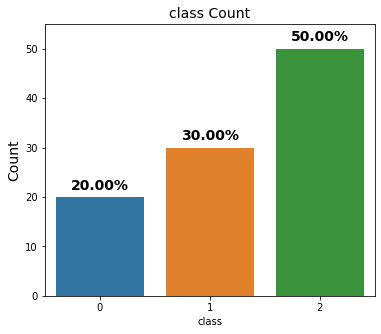

```python
total = len(df)

plt.figure(figsize=(13,5))
plt.subplot(121)
g = sns.countplot(x='class', data=df)
g.set_title("class Count", fontsize=14)
g.set_ylabel('Count', fontsize=14)
for p in g.patches:
    height = p.get_height()
    g.text(p.get_x()+p.get_width()/2.,
            height + 1.5,
            '{:1.2f}%'.format(height/total*100),
            ha="center", fontsize=14, fontweight='bold')
plt.margins(y=0.1)
plt.show()
```

```python
def plot_cv_indices(cv, X, y, ax, n_splits, lw=10):
    """Create a sample plot for indices of a cross-validation object."""

    # Generate the training/testing visualizations for each CV split
    for ii, (tr, tt) in enumerate(cv.split(X=X, y=y, groups=None)):
        # Fill in indices with the training/test groups
        indices = np.array([np.nan] * len(X))
        indices[tt] = 1
        indices[tr] = 0

        # Visualize the results
        ax.scatter(range(len(indices)), [ii + .5] * len(indices),
                   c=indices, marker='_', lw=lw, cmap=cmap_cv,
                   vmin=-.2, vmax=1.2)

    # Plot the data classes and groups at the end
    ax.scatter(range(len(X)), [ii + 1.5] * len(X),
               c=y, marker='_', lw=lw, cmap=cmap_data)

    # Formatting
    yticklabels = list(range(n_splits)) + ['class']
    ax.set(yticks=np.arange(n_splits+2) + .5, yticklabels=yticklabels,
           xlabel='Sample index', ylabel="CV iteration",
           ylim=[n_splits+1.2, -.1], xlim=[0, 100])
    ax.set_title('{}'.format(type(cv).__name__), fontsize=15)
    return ax
```

## Blocked and Time Series Split Cross-Validation

`Blocked cross-validation` works by adding margins at two positions. The first is between the training and validation folds in order to prevent the model from observing lag values which are used twice, once as an estimator (regressor) and another as a response. The second is between the folds used at each iteration in order to prevent the model from memorizing patterns from one iteration to the next.

- `Sci-kit learn` gives the luxury to define new types of splitters as long as you abide by its splitter API and inherit from the base splitter.

```python
class BlockingTimeSeriesSplit():
    def __init__(self, n_splits):
        self.n_splits = n_splits

    def get_n_splits(self, X, y, groups):
        return self.n_splits

    def split(self, X, y=None, groups=None):
        n_samples = len(X)
        k_fold_size = n_samples // self.n_splits
        indices = np.arange(n_samples)

        margin = 0
        for i in range(self.n_splits):
            start = i * k_fold_size
            stop = start + k_fold_size
            mid = int(0.5 * (stop - start)) + start
            yield indices[start: mid], indices[mid + margin: stop]
```

## Plot TimeSeriesSplit vs BlockingTimeSeriesSplit

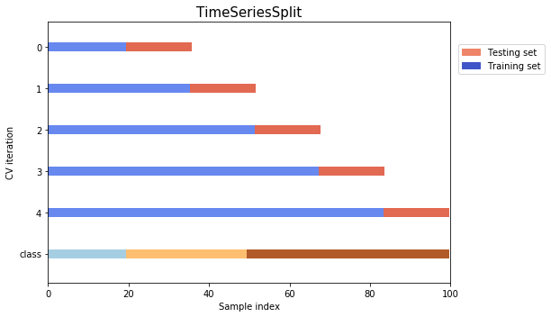

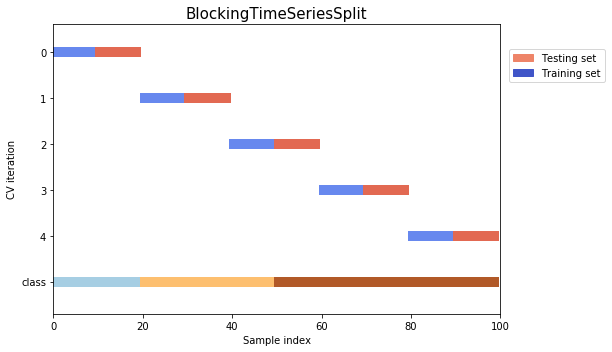

```python
cvs = [TimeSeriesSplit, BlockingTimeSeriesSplit]

for cv in cvs:
    this_cv = cv(n_splits=n_splits)
    fig, ax = plt.subplots(figsize=(10, 5))
    plot_cv_indices(this_cv, X, y, ax, n_splits)

    ax.legend([Patch(color=cmap_cv(.8)), Patch(color=cmap_cv(.02))],
            ['Testing set', 'Training set'], loc=(1.02, .8))
    plt.tight_layout()
    fig.subplots_adjust(right=.7)

plt.show()
```

The two split methods are depicted above. The horizontal axis is the training set size while the vertical axis represents the cross-validation iterations. The folds used for training are depicted in blue and the folds used for validation are depicted in orange. The final horizontal bar are the three class labels for the response variable.

# Crypto Data Set

I have obtained `ETH/USD` exchange prices up to the year `2020` from [cryptodatadownload](https://www.cryptodatadownload.com/)

```python
df = pd.read_csv('Gemini_ETHUSD_d.csv', skiprows=1, parse_dates=True, index_col='Date')
df = df.sort_index().drop('Symbol', axis=1)
df.head()
```

| Date | Open | High | Low | Close | Volume ETH | Volume USD |
| --- | --- | --- | --- | --- | --- | --- |
| 2016-05-09 | 12.00 | 12.00 | 9.36 | 9.98 | 1317.90 | 12885.06 |
| 2016-05-10 | 9.98 | 9.98 | 9.36 | 9.68 | 672.06 | 6578.20 |
| 2016-05-11 | 9.68 | 10.47 | 9.68 | 10.43 | 3052.51 | 30978.11 |
| 2016-05-12 | 10.43 | 12.00 | 9.92 | 10.20 | 2072.56 | 22183.39 |
| 2016-05-13 | 10.20 | 11.59 | 10.20 | 10.69 | 1769.71 | 18923.55 |

```python
STEPS = 9
```

```python
for i in np.arange(1 ,STEPS):
    col_name = '{}d_Fwd_Close'.format(i)
    df[col_name] = df['Close'].shift(-i)

df = df.dropna()
```

Next, we split the data frame into two one for the regressors and the other for the responses. And then split both into two one for training and the other for testing.

```python
Features = 6

X = df.iloc[:, :Features]
y = df.iloc[:, Features:]

split = int(len(df) * 0.7)

X_train = X[:split]
y_train = y[:split]

X_test = X[split:]
y_test = y[split:]
```

```python
X.head()
```

| Date | Open | High | Low | Close | Volume ETH | Volume USD |
| --- | --- | --- | --- | --- | --- | --- |
| 2016-05-09 | 12.00 | 12.00 | 9.36 | 9.98 | 1317.90 | 12885.06 |
| 2016-05-10 | 9.98 | 9.98 | 9.36 | 9.68 | 672.06 | 6578.20 |
| 2016-05-11 | 9.68 | 10.47 | 9.68 | 10.43 | 3052.51 | 30978.11 |
| 2016-05-12 | 10.43 | 12.00 | 9.92 | 10.20 | 2072.56 | 22183.39 |
| 2016-05-13 | 10.20 | 11.59 | 10.20 | 10.69 | 1769.71 | 18923.55 |

```python
y.head()
```

| Date | 1d_Fwd_Close | 2d_Fwd_Close | 3d_Fwd_Close | 4d_Fwd_Close | 5d_Fwd_Close | 6d_Fwd_Close | 7d_Fwd_Close | 8d_Fwd_Close |
| --- | --- | --- | --- | --- | --- | --- | --- | --- |
| 2016-05-09 | 9.68 | 10.43 | 10.20 | 10.69 | 10.25 | 10.06 | 11.37 | 12.23 |
| 2016-05-10 | 10.43 | 10.20 | 10.69 | 10.25 | 10.06 | 11.37 | 12.23 | 13.30 |
| 2016-05-11 | 10.20 | 10.69 | 10.25 | 10.06 | 11.37 | 12.23 | 13.30 | 14.50 |
| 2016-05-12 | 10.69 | 10.25 | 10.06 | 11.37 | 12.23 | 13.30 | 14.50 | 13.90 |
| 2016-05-13 | 10.25 | 10.06 | 11.37 | 12.23 | 13.30 | 14.50 | 13.90 | 13.97 |

# Model Design

Let’s define a method that creates an `elastic net` model from sci-kit learn and since we are going to forecast more than one future time step, we will use a `multi-output regressor` wrapper that trains a separate model for each target time step. This is a simple strategy for extending regressors that do not natively support multi-target regression. However, this introduces more demand for computation resources.

`Elastic Net` regression introduces both `L1-regularization` and `L2-regularization` to resolve overfitting and are also known as `Lasso` and `Ridge` regression respectively. Due to the trade offs of both Lasso and Ridge regression, Elastic Net regression was introduced to mix the two models. As a result, some of the variables coefficients are set to zero as per L1-norm and some others are penalized or shrunken as per the L2-norm.

This model combines the best from both regressors and the result is a more stable, robust, and sparse model. As a consequence, there are more parameters to be tuned.

```python
def build_model(_alpha, _l1_ratio):
    estimator = ElasticNet(
        alpha=_alpha,
        l1_ratio=_l1_ratio,
        fit_intercept=True,
        normalize=False,
        precompute=False,
        max_iter=16,
        copy_X=True,
        tol=0.1,
        warm_start=False,
        positive=False,
        random_state=None,
        selection='random'
    )

    return MultiOutputRegressor(estimator, n_jobs=4)
```

```python
sklearn.metrics.SCORERS.keys()
```

```
dict_keys(['explained_variance', 'r2', 'max_error', 'neg_median_absolute_error', 'neg_mean_absolute_error', 'neg_mean_squared_error', 'neg_mean_squared_log_error', 'accuracy', 'roc_auc', 'balanced_accuracy', 'average_precision', 'neg_log_loss', 'brier_score_loss', 'adjusted_rand_score', 'homogeneity…
```

**Time series splitter**

```python
model = build_model(_alpha=1.0, _l1_ratio=0.3)
tscv = TimeSeriesSplit(n_splits=5)
rmse = np.sqrt(-cross_val_score(model, X_train, y_train, cv=tscv, scoring='neg_mean_squared_error'))
R2 = cross_val_score(model, X_train, y_train, cv=tscv, scoring='r2')

print(f"RMSE: {rmse.mean()} (+/- {rmse.std()}")
print(f"\nR2: {R2.mean()} (+/- {R2.std()}")
```

```
RMSE: 56.75297352172712 (+/- 39.52438387000396

R2: 0.6965199572225272 (+/- 0.21016671547882793
```

**Blocking time series splitter**

```python
btscv = BlockingTimeSeriesSplit(n_splits=5)
rmse = np.sqrt(-cross_val_score(model, X_train, y_train, cv=btscv, scoring='neg_mean_squared_error'))
R2 = cross_val_score(model, X_train, y_train, cv=btscv, scoring='r2')

print(f"RMSE: {rmse.mean()} (+/- {rmse.std()}")
print(f"\nR2: {R2.mean()} (+/- {R2.std()}")
```

```
RMSE: 40.759129519772294 (+/- 33.4684769189527

R2: 0.5749318796458167 (+/- 0.3367378026776988
```

Notice how the loss is different among the different splitters. In order to interpret the results correctly, let’s put it to test by using grid search cross-validation to find the optimal values for both regularization parameter alpha and the ratio that controls how much norm contributes to the regularization.

# GridSearchCV

`GridSearchCV` works by exhaustively searching all the possible combinations of the model’s parameters, but it makes use of a loss function to guide the selection of the values to be tried at each iteration. That is solving a minimization optimization problem. However, in SciKit Learn it explicitly tries all the possible combinations which makes it very computationally expensive.

When **cross-validation** is used in the inner loop of the grid search, it is called grid search cross-validation. Hence, the optimization objective becomes minimizing the loss obtained on each of the k folds.

```python
def plot_grid_search(cv_results, grid_param_1, grid_param_2, name_param_1, name_param_2, best_params):

    # Get Test Scores Mean and std for each grid search
    scores_mean = cv_results['mean_test_score']
    scores_mean = np.array(scores_mean).reshape(len(grid_param_2),len(grid_param_1))

    scores_sd = cv_results['std_test_score']
    scores_sd = np.array(scores_sd).reshape(len(grid_param_2),len(grid_param_1))

    # Plot Grid search scores
    _, ax = plt.subplots(1,1)

    # Param1 is the X-axis, Param 2 is represented as a different curve (color line)
    for idx, val in enumerate(grid_param_2):
        ax.plot(grid_param_1, scores_mean[idx,:], '-o', label= name_param_2 + ': ' + str(val))

    ax.set_title(f"Grid Search Best Params: {best_params}", fontsize=12, fontweight='medium')
    ax.set_xlabel(name_param_1, fontsize=12)
    ax.set_ylabel('CV Average Score', fontsize=12)
    ax.legend(loc="best", fontsize=15)
    ax.grid('on')
    ax.legend(bbox_to_anchor=(1.02, 1.02))
```

**Time series splitter**

```python
model.get_params().keys()
```

```
dict_keys(['estimator__alpha', 'estimator__copy_X', 'estimator__fit_intercept', 'estimator__l1_ratio', 'estimator__max_iter', 'estimator__normalize', 'estimator__positive', 'estimator__precompute', 'estimator__random_state', 'estimator__selection', 'estimator__tol', 'estimator__warm_start', 'estimat…
```

```python
params = {
    'estimator__alpha':(0.1, 0.3, 0.5, 0.7, 0.9),
    'estimator__l1_ratio':(0.1, 0.3, 0.5, 0.7, 0.9)
}
```

```python
scores = []
for i in range(30):
    model = build_model(_alpha=1.0, _l1_ratio=0.3)

    finder = GridSearchCV(
        estimator=model,
        param_grid=params,
        scoring='r2',
        n_jobs=4,
        iid=False,
        refit=True,
        cv=tscv,  # change this to the splitter subject to test
        verbose=1,
        pre_dispatch=8,
        error_score=-999,
        return_train_score=True
        )

    finder.fit(X_train, y_train)

    best_params = finder.best_params_
    best_score = round(finder.best_score_,4)
    scores.append(best_score)
```

[output not shown]

[output not shown]

[output not shown]

[output not shown]

[output not shown]

[output not shown]

[output not shown]

[output not shown]

[output not shown]

[output not shown]

[output not shown]

[output not shown]

[output not shown]

[output not shown]

[output not shown]

[output not shown]

[output not shown]

[output not shown]

[output not shown]

[output not shown]

[output not shown]

[output not shown]

[output not shown]

[output not shown]

[output not shown]

[output not shown]

[output not shown]

[output not shown]

[output not shown]

[output not shown]

[output not shown]

[output not shown]

[output not shown]

[output not shown]

[output not shown]

[output not shown]

[output not shown]

[output not shown]

[output not shown]

[output not shown]

[output not shown]

[output not shown]

[output not shown]

[output not shown]

[output not shown]

[output not shown]

[output not shown]

[output not shown]

[output not shown]

[output not shown]

[output not shown]

[output not shown]

[output not shown]

[output not shown]

[output not shown]

[output not shown]

[output not shown]

[output not shown]

[output not shown]

[output not shown]

**Blocking time series splitter**

```python
scores0 = []
for i in range(30):
    model = build_model(_alpha=1.0, _l1_ratio=0.3)

    finder0 = GridSearchCV(
        estimator=model,
        param_grid=params,
        scoring='r2',
        n_jobs=4,
        iid=False,
        refit=True,
        cv=btscv,  # change this to the splitter subject to test
        verbose=1,
        pre_dispatch=8,
        error_score=-999,
        return_train_score=True
        )

    finder0.fit(X_train, y_train)

    best_params0 = finder0.best_params_
    best_score0 = round(finder0.best_score_,4)
    scores0.append(best_score)
```

[output not shown]

[output not shown]

[output not shown]

[output not shown]

[output not shown]

[output not shown]

[output not shown]

[output not shown]

[output not shown]

[output not shown]

[output not shown]

[output not shown]

[output not shown]

[output not shown]

[output not shown]

[output not shown]

[output not shown]

[output not shown]

[output not shown]

[output not shown]

[output not shown]

[output not shown]

[output not shown]

[output not shown]

[output not shown]

[output not shown]

[output not shown]

[output not shown]

[output not shown]

[output not shown]

[output not shown]

[output not shown]

[output not shown]

[output not shown]

[output not shown]

[output not shown]

[output not shown]

[output not shown]

[output not shown]

[output not shown]

[output not shown]

[output not shown]

[output not shown]

[output not shown]

[output not shown]

[output not shown]

[output not shown]

[output not shown]

[output not shown]

[output not shown]

[output not shown]

[output not shown]

[output not shown]

[output not shown]

[output not shown]

[output not shown]

[output not shown]

[output not shown]

[output not shown]

[output not shown]

```python
finder0.cv_results_.keys()
```

```
dict_keys(['mean_fit_time', 'std_fit_time', 'mean_score_time', 'std_score_time', 'param_estimator__alpha', 'param_estimator__l1_ratio', 'params', 'split0_test_score', 'split1_test_score', 'split2_test_score', 'split3_test_score', 'split4_test_score', 'mean_test_score', 'std_test_score', 'rank_test_s…
```

# Results

```
Time series splitter best score: 0.714
```

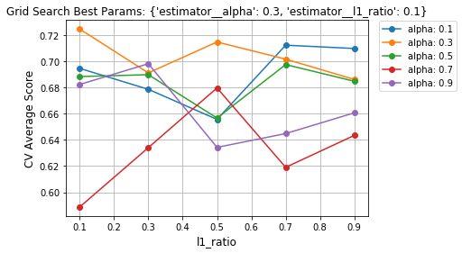

```python
scores1 = pd.DataFrame(scores)
bs = round(float(scores1.mean()),4)
print(f'\nTime series splitter best score: {bs}')

plot_grid_search(finder.cv_results_, params['estimator__l1_ratio'], params['estimator__alpha'],
                 'l1_ratio', 'alpha', best_params)
```

```
Blocking time series splitter best score: 0.7245
```

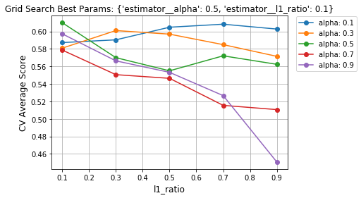

```python
scores01 = pd.DataFrame(scores0)
bs0 = round(float(scores01.mean()),4)
print(f'\nBlocking time series splitter best score: {bs0}')

plot_grid_search(finder0.cv_results_, params['estimator__l1_ratio'], params['estimator__alpha'],
                 'l1_ratio', 'alpha', best_params0)
```

In both the cases of time series split cross-validation and blocked cross-validation, we have obtained a clear indication of the optimal values for both parameters. In case of blocked cross-validation, the results were even more discriminative as there is a clearer and more consistent drop off as l1 ratio values increase with respect to alpha values.

```python
preds = pd.DataFrame(finder.predict(X_test), columns=df.iloc[:, Features:].columns)
preds.head()
```

|  | 1d_Fwd_Close | 2d_Fwd_Close | 3d_Fwd_Close | 4d_Fwd_Close | 5d_Fwd_Close | 6d_Fwd_Close | 7d_Fwd_Close | 8d_Fwd_Close |
| --- | --- | --- | --- | --- | --- | --- | --- | --- |
| 0 | 121.124623 | 121.133478 | 120.734223 | 119.695900 | 129.216379 | 124.016077 | 124.117680 | 125.920169 |
| 1 | 123.084550 | 122.862757 | 122.151594 | 120.750844 | 126.333414 | 125.406969 | 125.501370 | 124.268494 |
| 2 | 120.085939 | 123.001682 | 121.977905 | 116.692940 | 122.701168 | 125.025789 | 125.193181 | 121.832818 |
| 3 | 120.354948 | 119.790353 | 118.580918 | 115.806696 | 121.439701 | 121.306727 | 121.573581 | 119.934876 |
| 4 | 121.711769 | 123.922155 | 122.820337 | 117.599744 | 124.967223 | 125.522764 | 125.706135 | 123.185545 |

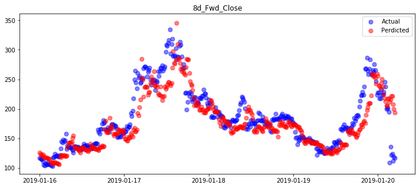

```python
fig, ax = plt.subplots(figsize=(12,5))
ax.scatter(preds.index, y_test['8d_Fwd_Close'], color='b', alpha=0.5, label='Actual', s=50)
ax.scatter(preds.index, preds['8d_Fwd_Close'], color='r', alpha=0.5, label='Perdicted', s=50)
ax.set_xticklabels(df[split:].index.strftime('%Y-%m-%d'))
ax.set_title('8d_Fwd_Close')
ax.legend()
plt.show()
```

```python
model = build_model(_alpha=1.0, _l1_ratio=0.3)
rmse = np.sqrt(-cross_val_score(model, X_test, y_test, cv=tscv, scoring='neg_mean_squared_error'))
R2 = cross_val_score(model, X_test, y_test, cv=tscv, scoring='r2')

print(f"RMSE: {rmse.mean()} (+/- {rmse.std()}")
print(f"\nR2: {R2.mean()} (+/- {R2.std()}")
```

```
RMSE: 23.23101772055727 (+/- 7.725460399491488

R2: 0.37692919884847687 (+/- 0.4119088912942127
```

**Trianing Dates for BlockingTimeSeriesSplit**

```python
btss = BlockingTimeSeriesSplit(n_splits=12)

for tr_idx, val_idx in btss.split(X, y):

    X_tr, X_vl = X.iloc[tr_idx], X.iloc[val_idx]

    print('Train:')
    print(X_tr.info())
    print()
    print('Test:')
    print(X_vl.info())
    print()
```

```
Train:
<class 'pandas.core.frame.DataFrame'>
DatetimeIndex: 58 entries, 2016-05-09 to 2016-07-05
Data columns (total 6 columns):
Open          58 non-null float64
High          58 non-null float64
Low           58 non-null float64
Close         58 non-null float64
Volume ETH    58 non-null float64
Volume USD    58 non-null float64
dtypes: float64(6)
memory usage: 3.2 KB
None

Test:
<class 'pandas.core.frame.DataFrame'>
DatetimeIndex: 58 entries, 2016-07-06 to 2016-09-01
Data columns (total 6 columns):
Open          58 non-null float64
High          58 non-null float64
Low           58 non-null float64
Close         58 non-null float64
Volume ETH    58 non-null float64
Volume USD    58 non-null float64
dtypes: float64(6)
memory usage: 3.2 KB
None

Train:
<class 'pandas.core.frame.DataFrame'>
DatetimeIndex: 58 entries, 2016-09-02 to 2016-10-29
Data columns (total 6 columns):
Open          58 non-null float64
High          58 non-null float64
Low           58 non-null float64
Close         58 non-null float64
Volume ETH    58 non-null float64
Volume USD    58 non-null float64
dtypes: float64(6)
memory usage: 3.2 KB
```

[output cut: 280 more lines]

```
None

Test:
<class 'pandas.core.frame.DataFrame'>
DatetimeIndex: 58 entries, 2020-01-03 to 2020-02-29
Data columns (total 6 columns):
Open          58 non-null float64
High          58 non-null float64
Low           58 non-null float64
Close         58 non-null float64
Volume ETH    58 non-null float64
Volume USD    58 non-null float64
dtypes: float64(6)
memory usage: 3.2 KB
None
```

**Trianing Dates for TimeSeriesSplit**

```python
tss = TimeSeriesSplit(n_splits=23)

for tr_idx, val_idx in tss.split(X, y):

    X_tr, X_vl = X.iloc[tr_idx], X.iloc[val_idx]

    print('Train:')
    print(X_tr.info())
    print()
    print('Test:')
    print(X_vl.info())
    print()
```

```
Train:
<class 'pandas.core.frame.DataFrame'>
DatetimeIndex: 68 entries, 2016-05-09 to 2016-07-15
Data columns (total 6 columns):
Open          68 non-null float64
High          68 non-null float64
Low           68 non-null float64
Close         68 non-null float64
Volume ETH    68 non-null float64
Volume USD    68 non-null float64
dtypes: float64(6)
memory usage: 3.7 KB
None

Test:
<class 'pandas.core.frame.DataFrame'>
DatetimeIndex: 58 entries, 2016-07-16 to 2016-09-11
Data columns (total 6 columns):
Open          58 non-null float64
High          58 non-null float64
Low           58 non-null float64
Close         58 non-null float64
Volume ETH    58 non-null float64
Volume USD    58 non-null float64
dtypes: float64(6)
memory usage: 3.2 KB
None

Train:
<class 'pandas.core.frame.DataFrame'>
DatetimeIndex: 126 entries, 2016-05-09 to 2016-09-11
Data columns (total 6 columns):
Open          126 non-null float64
High          126 non-null float64
Low           126 non-null float64
Close         126 non-null float64
Volume ETH    126 non-null float64
Volume USD    126 non-null float64
dtypes: float64(6)
memory usage: 6.9 KB
```

[output cut: 588 more lines]

```
None

Test:
<class 'pandas.core.frame.DataFrame'>
DatetimeIndex: 58 entries, 2020-01-13 to 2020-03-10
Data columns (total 6 columns):
Open          58 non-null float64
High          58 non-null float64
Low           58 non-null float64
Close         58 non-null float64
Volume ETH    58 non-null float64
Volume USD    58 non-null float64
dtypes: float64(6)
memory usage: 3.2 KB
None
```